# Football betting data

Roudranil Das

2022-09-07

```r
library(tidyverse)
data <- read.csv("E0.csv", header = T)
## FTHG: full time home goals
FTHG <- data[,"FTHG"]
freq_table <- table(FTHG)
freq_table
```

```
## FTHG
##   0   1   2   3   4   5   6   7
##  93 121  89  50  15   8   2   2
```

**Using this data we would like to find out the probability that in 22-23, there will be a match where the home team will score 8 or more goals?**

Based on this data, we would say that the prob is 0, but that is not the case. Lets model using a distribution. Candidates:  
1. Poisson  
2. Geometric  
3. Negative binomial

Let $X: FTHG$. Then say assume $X \sim Poisson(\lambda)$. Then we want to find out
$$P[X \geq 8] = 1 - P[X \leq
7]$$

**Using method of moments**  
We know that $E[X] = \lambda$. Sample mean is a good guess for the population mean. Thus

```r
lambda_hat = mean(FTHG)
lambda_hat
```

```
## [1] 1.513158
```

This method is not really suitable for many distributions. Hence we would be using the likelihood method.

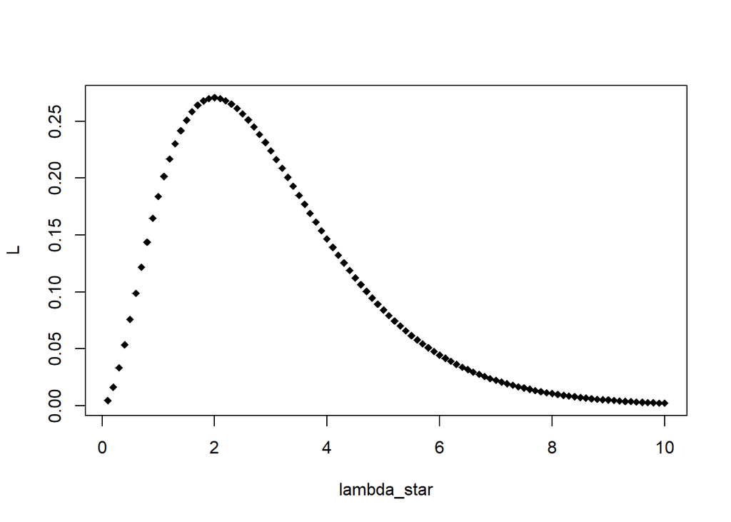

```r
x1 = FTHG[1]
lambda_star = seq(0.1, 10, length.out = 100)
L = dpois(x1, lambda = lambda_star)
plot(lambda_star, L, pch = 18)
```

For maximum likelihood, $P[D\mid \lambda] = P[X_1 = x_1, X_2 = x_2,\ldots,X_n = x_n \mid \lambda]$. Assuming independence (*SRSWR*). Thus $P[D\mid \lambda] = P[X_1 = x_1\mid \lambda]\cdot P[X_2 = x_2\mid \lambda]\cdots\cdot P[X_n = x_n \mid \lambda]$. However just multiply will be a problem, because as n increases the likelihood will go to 0, but even if it is not 0, it will be rounded to 0 due to computation. To circumvent this, we take the loglikelihood.

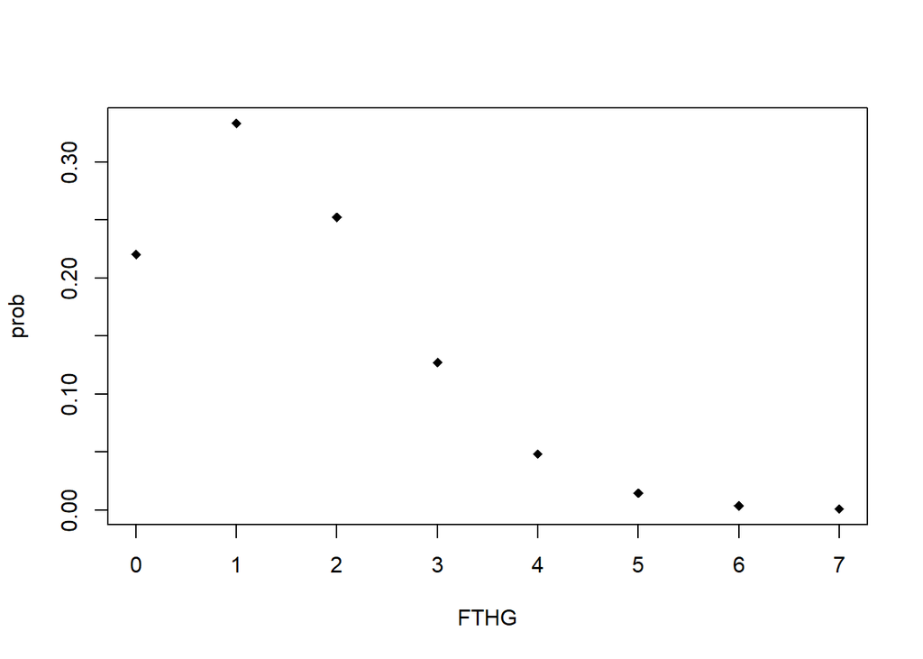

```r
prob = dpois(FTHG, lambda = lambda_hat)
plot(FTHG, prob, pch = 18)
```

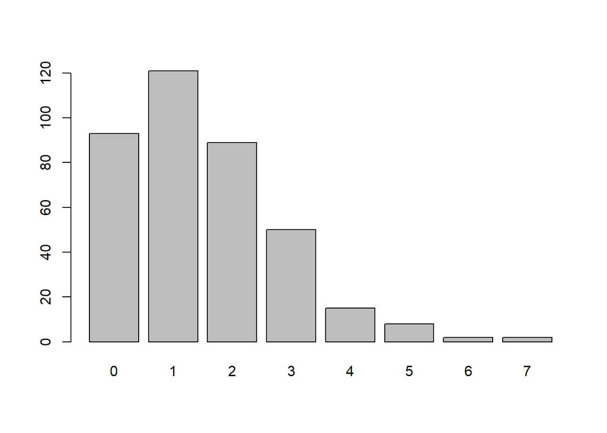

```r
barplot(freq_table)
```

$P(X=x) = e^{-\lambda}\frac{\lambda^x}{x!}$. Hence $\log P[X=x] = -\lambda + x\cdot \log \lambda - \log x!$.

```r
log_likelihood_poisson = function(lambda, data){
    n = length(data) # number of samples
    loglike = sum(dpois(x = data, lambda = lambda, log = T))
    return(loglike)
}
log_likelihood_poisson(lambda = 2, data = FTHG)
```

```
## [1] -628.898
```

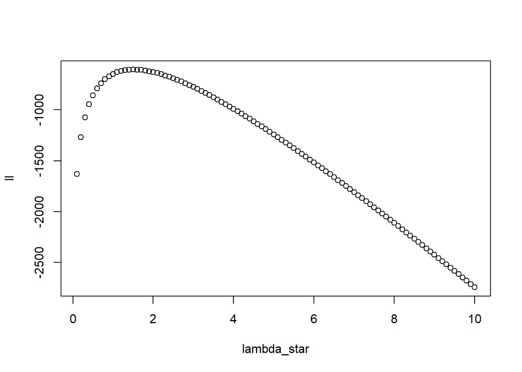

```r
ll = c()
for(l in lambda_star){
    ll = append(ll, log_likelihood_poisson(lambda = l, data = FTHG))
}
plot(lambda_star, ll)
```

```r
best_value = lambda_star[which.max(ll)]
best_value
```

```
## [1] 1.5
```

### Optimising this code

For optimising one variable `optimise`; for optimising many variables `optim`

```r
optimise(log_likelihood_poisson, c(0,10), maximum = T, data = FTHG)
```

```
## $maximum
## [1] 1.513146
##
## $objective
## [1] -604.2933
```